# R Notebook

PRIMERO

```r
rm(list = ls())
```

La data de este [link](https://www.ceplan.gob.pe/informacion-sobre-zonas-y-departamentos-del-peru/)

Se ha llevado a un repo de [GitHub](https://github.com/eap-repasos/repaso_ceplan)

Descargue:

```r
# Nota el 'raw' en el link
linkDescarga="https://github.com/eap-repasos/repaso_ceplan/raw/refs/heads/main/0.Nacional_Datos-para-el-planeamiento-estrategico_29072021.xlsx"

# para excel:
library(rio)
# hoja '3' es la provincial
ceplanAll=rio::import(linkDescarga,which = 3)
class(ceplanAll)
```

```
## [1] "data.frame"
```

## Filas necesarias

Recupera los titulos si se han perdido:

```r
head(ceplanAll,10)
```

|  | ...1 | Perú: datos para el planeamiento estratégico, provincial. | ...3 | ...4 | ...5 | ...6 | ...7 | ...8 | ...9 | ...10 | ...11 | ...12 | ...13 | ...14 | ...15 | ...16 | ...17 | ...18 | ...19 | ...20 | ...21 | ...22 | ...23 | ...24 | ...25 | ...26 | ...27 | ...28 | ...29 | … |
| --- | --- | --- | --- | --- | --- | --- | --- | --- | --- | --- | --- | --- | --- | --- | --- | --- | --- | --- | --- | --- | --- | --- | --- | --- | --- | --- | --- | --- | --- | --- |
| 1 | NA | NA | NA | NA | NA | NA | NA | NA | NA | NA | NA | NA | NA | NA | NA | NA | NA | NA | NA | NA | NA | NA | NA | NA | NA | NA | NA | NA | NA | … |
| 2 | NA | NA | NA | POBLACIÓN | NA | NA | NA | NA | NA | TERRITORIO | NA | NA | NA | NA | NA | NA | NA | NA | NA | NA | NA | NACIDOS VIVOS | NA | NA | NA | NA | NA | NA | SITUACIÓN ALIMENTARIO NUTRICIONAL | … |
| 3 | NA | Ubigeo | Región /\r\nProvincia | Población total\r\n(2007)\r\n1a/ | Población total\r\n(2017)\r\n1a/ | Población total\r\n(2020)\r\n1b/ | Población de niños menores de un año\r\n(CENSO 2017)\r\n1a/ | Población mayor de 80 años \r\n(2020)\r\n1b/ | Población con Discapacidad\r\n(2020)\r\n1c/ | Superficie (km2) \r\n2/ | Densidad\r\n(2020) | Capital legal \r\n3/ | Altitud (msnm)\r\n 3/ | Latitud\r\nsur\r\n 3/ | Longitud oeste\r\n 3/ | Tipología de distrito según SDOT\r\n4/ | Centro Fucional de Organización Territorial\r\n4a/ | Número de Provincias 3/ | Número de Distritos \r\n3/ | Número de Centros Poblados\r\n3/ | País fronterizo | Población de niños menores de un año\r\n(CENSO 2017)\r\n1a/ | Número anual de nacidos vivos según distrito de residencia habitual de la madre (2020)\r\n5/ | Número anual de nacidos vivos con bajo peso según distrito de residencia habitual de la madre (2020)\r\n5/ | Porcentaje de nacidos vivos con bajo peso al nacer (2020)\r\n5/ 6/ | Total | Número de niños menores de un año con DNI emitido hasta los 30 días de nacido (2020)\r\n7/ | Porcentaje de niños menores de un año con DNI emitido hasta los 30 días de nacido (al 2021)\r\n7/ | Índice de Vulnerabilidad a la Inseguridad Alimentaria (IVIA) \r\n(2018)\r\n8/ | … |
| 4 | Nacional | NACIONAL | NA | 28481901 | 31237385 | 34393444 | 493495 | 628342 | 297030 | 1280172.28 | 26.866262094036301 | NA | NA | NA | NA | - | NA | 196 | 1874 | 94922 | - | 493495 | 460712 | 27823 | 6.0391307367726501 | 383860 | 28251 | 7.35971447923722 | 0.49689161300659201 | … |
| 5 | Nacional_esp | NACIONAL SIN LA PROV. DE LIMA | NA | 20620156 | 22075063 | 24188630 | 371675 | 434258 | 217586 | 1277557.1200000001 | 18.933501775638799 | NA | NA | NA | NA | - | NA | 195 | 1831 | 94811 | - | 371675 | 330104 | 20982 | 6.3561786588469102 | 297857 | 20780 | 6.9765021470034299 | - | … |
| 6 | Región | 150000 | LIMA | 8730820 | 10135009 | 11261067 | 137218 | 217672 | 88625 | 34823.519999999997 | 323.37532219603298 | Lima | 162.41999999999999 | -12.0452777777778 | -77.030833333333305 | - | NA | 10 | 171 | 5229 | No | 137218 | 144830 | 7499 | 5.1777946558033596 | 97559 | 7707 | 7.8998349716581799 | 0.26664412021637002 | … |
| 7 | Zona | ZONA NORTE | NA | 8367388 | 8987709 | 9962022 | 162076 | 171114 | 84289 | 572940.32999999996 | 17.387538419576799 | NA | NA | NA | NA | - | NA | 64 | 540 | 22540 | - | 162076 | 123503 | 8942 | 7.2403099519849698 | 126022 | 7110 | 5.6418720540857903 | - | … |
| 8 | Región | 010000 | AMAZONAS | 406087 | 417365 | 472993 | 8043 | 7743 | 7826 | 39249.129999999997 | 12.0510441887502 | Chachapoyas | 2338 | -6.2294444444444501 | -77.872777777777699 | - | NA | 7 | 84 | 3174 | Ecuador | 8043 | 5113 | 365 | 7.13866614512028 | 5600 | 184 | 3.28571428571429 | 0.86835986375808705 | … |
| 9 | Provincia | 010200 | BAGUA | 77637 | 82193 | 98110 | 1636 | 1217 | 1586 | 5652.72 | 17.356246196521301 | Bagua | 408 | -5.6388888888888902 | -78.531111111111102 | - | NA | - | 6 | 345 | Ecuador | 1636 | 1077 | 69 | 6.4066852367687996 | 986 | 13 | 1.3184584178498999 | 0.51947927474975597 | … |
| 10 | Provincia | 010300 | BONGARÁ | 29552 | 27085 | 29335 | 397 | 655 | 398 | 2869.65 | 10.2225010018643 | Jumbilla | 2081 | -5.9044444444444499 | -77.797777777777796 | - | NA | - | 12 | 291 | No | 397 | 401 | 20 | 4.9875311720698301 | 343 | 4 | 1.1661807580174901 | 0.50935518741607699 | … |

como los nombres estan en la tercera fila:

```r
ceplanAll[3,]
```

|  | ...1 | Perú: datos para el planeamiento estratégico, provincial. | ...3 | ...4 | ...5 | ...6 | ...7 | ...8 | ...9 | ...10 | ...11 | ...12 | ...13 | ...14 | ...15 | ...16 | ...17 | ...18 | ...19 | ...20 | ...21 | ...22 | ...23 | ...24 | ...25 | ...26 | ...27 | ...28 | ...29 | … |
| --- | --- | --- | --- | --- | --- | --- | --- | --- | --- | --- | --- | --- | --- | --- | --- | --- | --- | --- | --- | --- | --- | --- | --- | --- | --- | --- | --- | --- | --- | --- |
| 3 | NA | Ubigeo | Región /\r\nProvincia | Población total\r\n(2007)\r\n1a/ | Población total\r\n(2017)\r\n1a/ | Población total\r\n(2020)\r\n1b/ | Población de niños menores de un año\r\n(CENSO 2017)\r\n1a/ | Población mayor de 80 años \r\n(2020)\r\n1b/ | Población con Discapacidad\r\n(2020)\r\n1c/ | Superficie (km2) \r\n2/ | Densidad\r\n(2020) | Capital legal \r\n3/ | Altitud (msnm)\r\n 3/ | Latitud\r\nsur\r\n 3/ | Longitud oeste\r\n 3/ | Tipología de distrito según SDOT\r\n4/ | Centro Fucional de Organización Territorial\r\n4a/ | Número de Provincias 3/ | Número de Distritos \r\n3/ | Número de Centros Poblados\r\n3/ | País fronterizo | Población de niños menores de un año\r\n(CENSO 2017)\r\n1a/ | Número anual de nacidos vivos según distrito de residencia habitual de la madre (2020)\r\n5/ | Número anual de nacidos vivos con bajo peso según distrito de residencia habitual de la madre (2020)\r\n5/ | Porcentaje de nacidos vivos con bajo peso al nacer (2020)\r\n5/ 6/ | Total | Número de niños menores de un año con DNI emitido hasta los 30 días de nacido (2020)\r\n7/ | Porcentaje de niños menores de un año con DNI emitido hasta los 30 días de nacido (al 2021)\r\n7/ | Índice de Vulnerabilidad a la Inseguridad Alimentaria (IVIA) \r\n(2018)\r\n8/ | … |

Reemplazamos:

```r
names(ceplanAll)=ceplanAll[3,]
head(ceplanAll)
```

|  | None | Ubigeo | Región / Provincia | Población total (2007) 1a/ | Población total (2017) 1a/ | Población total (2020) 1b/ | Población de niños menores de un año (CENSO 2017) 1a/ | Población mayor de 80 años (2020) 1b/ | Población con Discapacidad (2020) 1c/ | Superficie (km2) 2/ | Densidad (2020) | Capital legal 3/ | Altitud (msnm) 3/ | Latitud sur 3/ | Longitud oeste 3/ | Tipología de distrito según SDOT 4/ | Centro Fucional de Organización Territorial 4a/ | Número de Provincias 3/ | Número de Distritos 3/ | Número de Centros Poblados 3/ | País fronterizo | Población de niños menores de un año (CENSO 2017) 1a/ | Número anual de nacidos vivos según distrito de residencia habitual de la madre (2020) 5/ | Número anual de nacidos vivos con bajo peso según distrito de residencia habitual de la madre (2020) 5/ | Porcentaje de nacidos vivos con bajo peso al nacer (2020) 5/ 6/ | Total | Número de niños menores de un año con DNI emitido hasta los 30 días de nacido (2020) 7/ | Porcentaje de niños menores de un año con DNI emitido hasta los 30 días de nacido (al 2021) 7/ | Índice de Vulnerabilidad a la Inseguridad Alimentaria (IVIA) (2018) 8/ | … |
| --- | --- | --- | --- | --- | --- | --- | --- | --- | --- | --- | --- | --- | --- | --- | --- | --- | --- | --- | --- | --- | --- | --- | --- | --- | --- | --- | --- | --- | --- | --- |
| 1 | NA | NA | NA | NA | NA | NA | NA | NA | NA | NA | NA | NA | NA | NA | NA | NA | NA | NA | NA | NA | NA | NA | NA | NA | NA | NA | NA | NA | NA | … |
| 2 | NA | NA | NA | POBLACIÓN | NA | NA | NA | NA | NA | TERRITORIO | NA | NA | NA | NA | NA | NA | NA | NA | NA | NA | NA | NACIDOS VIVOS | NA | NA | NA | NA | NA | NA | SITUACIÓN ALIMENTARIO NUTRICIONAL | … |
| 3 | NA | Ubigeo | Región /\r\nProvincia | Población total\r\n(2007)\r\n1a/ | Población total\r\n(2017)\r\n1a/ | Población total\r\n(2020)\r\n1b/ | Población de niños menores de un año\r\n(CENSO 2017)\r\n1a/ | Población mayor de 80 años \r\n(2020)\r\n1b/ | Población con Discapacidad\r\n(2020)\r\n1c/ | Superficie (km2) \r\n2/ | Densidad\r\n(2020) | Capital legal \r\n3/ | Altitud (msnm)\r\n 3/ | Latitud\r\nsur\r\n 3/ | Longitud oeste\r\n 3/ | Tipología de distrito según SDOT\r\n4/ | Centro Fucional de Organización Territorial\r\n4a/ | Número de Provincias 3/ | Número de Distritos \r\n3/ | Número de Centros Poblados\r\n3/ | País fronterizo | Población de niños menores de un año\r\n(CENSO 2017)\r\n1a/ | Número anual de nacidos vivos según distrito de residencia habitual de la madre (2020)\r\n5/ | Número anual de nacidos vivos con bajo peso según distrito de residencia habitual de la madre (2020)\r\n5/ | Porcentaje de nacidos vivos con bajo peso al nacer (2020)\r\n5/ 6/ | Total | Número de niños menores de un año con DNI emitido hasta los 30 días de nacido (2020)\r\n7/ | Porcentaje de niños menores de un año con DNI emitido hasta los 30 días de nacido (al 2021)\r\n7/ | Índice de Vulnerabilidad a la Inseguridad Alimentaria (IVIA) \r\n(2018)\r\n8/ | … |
| 4 | Nacional | NACIONAL | NA | 28481901 | 31237385 | 34393444 | 493495 | 628342 | 297030 | 1280172.28 | 26.866262094036301 | NA | NA | NA | NA | - | NA | 196 | 1874 | 94922 | - | 493495 | 460712 | 27823 | 6.0391307367726501 | 383860 | 28251 | 7.35971447923722 | 0.49689161300659201 | … |
| 5 | Nacional_esp | NACIONAL SIN LA PROV. DE LIMA | NA | 20620156 | 22075063 | 24188630 | 371675 | 434258 | 217586 | 1277557.1200000001 | 18.933501775638799 | NA | NA | NA | NA | - | NA | 195 | 1831 | 94811 | - | 371675 | 330104 | 20982 | 6.3561786588469102 | 297857 | 20780 | 6.9765021470034299 | - | … |
| 6 | Región | 150000 | LIMA | 8730820 | 10135009 | 11261067 | 137218 | 217672 | 88625 | 34823.519999999997 | 323.37532219603298 | Lima | 162.41999999999999 | -12.0452777777778 | -77.030833333333305 | - | NA | 10 | 171 | 5229 | No | 137218 | 144830 | 7499 | 5.1777946558033596 | 97559 | 7707 | 7.8998349716581799 | 0.26664412021637002 | … |

Revisa la ‘cola’:

```r
tail(ceplanAll,20)
```

|  | None | Ubigeo | Región / Provincia | Población total (2007) 1a/ | Población total (2017) 1a/ | Población total (2020) 1b/ | Población de niños menores de un año (CENSO 2017) 1a/ | Población mayor de 80 años (2020) 1b/ | Población con Discapacidad (2020) 1c/ | Superficie (km2) 2/ | Densidad (2020) | Capital legal 3/ | Altitud (msnm) 3/ | Latitud sur 3/ | Longitud oeste 3/ | Tipología de distrito según SDOT 4/ | Centro Fucional de Organización Territorial 4a/ | Número de Provincias 3/ | Número de Distritos 3/ | Número de Centros Poblados 3/ | País fronterizo | Población de niños menores de un año (CENSO 2017) 1a/ | Número anual de nacidos vivos según distrito de residencia habitual de la madre (2020) 5/ | Número anual de nacidos vivos con bajo peso según distrito de residencia habitual de la madre (2020) 5/ | Porcentaje de nacidos vivos con bajo peso al nacer (2020) 5/ 6/ | Total | Número de niños menores de un año con DNI emitido hasta los 30 días de nacido (2020) 7/ | Porcentaje de niños menores de un año con DNI emitido hasta los 30 días de nacido (al 2021) 7/ | Índice de Vulnerabilidad a la Inseguridad Alimentaria (IVIA) (2018) 8/ | … |
| --- | --- | --- | --- | --- | --- | --- | --- | --- | --- | --- | --- | --- | --- | --- | --- | --- | --- | --- | --- | --- | --- | --- | --- | --- | --- | --- | --- | --- | --- | --- |
| 240 | NA | Elaboración: Centro Nacional de Planeamiento Estratégico (CEPLAN) - Dirección Nacional de Seguimiento y Evaluación (DNSE) | NA | NA | NA | NA | NA | NA | NA | NA | NA | NA | NA | NA | NA | NA | NA | NA | NA | NA | NA | NA | NA | NA | NA | NA | NA | NA | NA | … |
| 241 | NA | Fecha de actualización: 29 de julio de 2021 | NA | NA | NA | NA | NA | NA | NA | NA | NA | NA | NA | NA | NA | NA | NA | NA | NA | NA | NA | NA | NA | NA | NA | NA | NA | NA | NA | … |
| 242 | NA | NA | NA | NA | NA | NA | NA | NA | NA | NA | NA | NA | NA | NA | NA | NA | NA | NA | NA | NA | NA | NA | NA | NA | NA | NA | NA | NA | NA | … |
| 243 | NA | NA | NA | NA | NA | NA | NA | NA | NA | NA | NA | NA | NA | NA | NA | NA | NA | NA | NA | NA | NA | NA | NA | NA | NA | NA | NA | NA | NA | … |
| 244 | NA | Leyenda de colores | NA | NA | NA | NA | NA | NA | NA | NA | NA | NA | NA | NA | NA | NA | NA | NA | NA | NA | NA | NA | NA | NA | NA | NA | NA | NA | NA | … |
| 245 | NA | NA | NA | NA | NA | NA | NA | NA | NA | NA | NA | NA | NA | NA | NA | NA | NA | NA | NA | NA | NA | NA | NA | NA | NA | NA | NA | NA | NA | … |
| 246 | NA | NA | ZONA NORTE | NA | NA | NA | NA | NA | NA | NA | NA | NA | NA | NA | NA | NA | NA | NA | NA | NA | NA | NA | NA | NA | NA | NA | NA | NA | NA | … |
| 247 | NA | NA | DEPARTAMENTO | NA | NA | NA | NA | NA | NA | NA | NA | NA | NA | NA | NA | NA | NA | NA | NA | NA | NA | NA | NA | NA | NA | NA | NA | NA | NA | … |
| 248 | NA | NA | PROVINCIA | NA | NA | NA | NA | NA | NA | NA | NA | NA | NA | NA | NA | NA | NA | NA | NA | NA | NA | NA | NA | NA | NA | NA | NA | NA | NA | … |
| 249 | NA | NA | DISTRITO | NA | NA | NA | NA | NA | NA | NA | NA | NA | NA | NA | NA | NA | NA | NA | NA | NA | NA | NA | NA | NA | NA | NA | NA | NA | NA | … |

[output cut: 10 more lines]

Mira columna 1:

```r
ceplanAll[,1]
```

```
##   [1] NA               NA               NA               "Nacional"
##   [5] "Nacional_esp"   "Región"         "Zona"           "Región"
##   [9] "Provincia"      "Provincia"      "Provincia"      "Provincia"
##  [13] "Provincia"      "Provincia"      "Provincia"      "Región"
##  [17] "Provincia"      "Provincia"      "Provincia"      "Provincia"
##  [21] "Provincia"      "Provincia"      "Provincia"      "Provincia"
##  [25] "Provincia"      "Provincia"      "Provincia"      "Provincia"
##  [29] "Provincia"      "Región"         "Provincia"      "Provincia"
##  [33] "Provincia"      "Provincia"      "Provincia"      "Provincia"
##  [37] "Provincia"      "Provincia"      "Provincia"      "Provincia"
##  [41] "Provincia"      "Provincia"      "Región"         "Provincia"
##  [45] "Provincia"      "Provincia"      "Región"         "Provincia"
##  [49] "Provincia"      "Provincia"      "Provincia"      "Provincia"
##  [53] "Provincia"      "Provincia"      "Provincia"      "Región"
##  [57] "Provincia"      "Provincia"      "Provincia"      "Provincia"
```

[output cut: 50 more lines]

**ESA COLUMNS** te servirá para eliminar filas vacias:

```r
ceplanFilasOK=ceplanAll[!is.na(ceplanAll[,1]),]
ceplanFilasOK
```

|  | None | Ubigeo | Región / Provincia | Población total (2007) 1a/ | Población total (2017) 1a/ | Población total (2020) 1b/ | Población de niños menores de un año (CENSO 2017) 1a/ | Población mayor de 80 años (2020) 1b/ | Población con Discapacidad (2020) 1c/ | Superficie (km2) 2/ | Densidad (2020) | Capital legal 3/ | Altitud (msnm) 3/ | Latitud sur 3/ | Longitud oeste 3/ | Tipología de distrito según SDOT 4/ | Centro Fucional de Organización Territorial 4a/ | Número de Provincias 3/ | Número de Distritos 3/ | Número de Centros Poblados 3/ | País fronterizo | Población de niños menores de un año (CENSO 2017) 1a/ | Número anual de nacidos vivos según distrito de residencia habitual de la madre (2020) 5/ | Número anual de nacidos vivos con bajo peso según distrito de residencia habitual de la madre (2020) 5/ | Porcentaje de nacidos vivos con bajo peso al nacer (2020) 5/ 6/ | Total | Número de niños menores de un año con DNI emitido hasta los 30 días de nacido (2020) 7/ | Porcentaje de niños menores de un año con DNI emitido hasta los 30 días de nacido (al 2021) 7/ | Índice de Vulnerabilidad a la Inseguridad Alimentaria (IVIA) (2018) 8/ | … |
| --- | --- | --- | --- | --- | --- | --- | --- | --- | --- | --- | --- | --- | --- | --- | --- | --- | --- | --- | --- | --- | --- | --- | --- | --- | --- | --- | --- | --- | --- | --- |
| 4 | Nacional | NACIONAL | NA | 28481901 | 31237385 | 34393444 | 493495 | 628342 | 297030 | 1280172.28 | 26.866262094036301 | NA | NA | NA | NA | - | NA | 196 | 1874 | 94922 | - | 493495 | 460712 | 27823 | 6.0391307367726501 | 383860 | 28251 | 7.35971447923722 | 0.49689161300659201 | … |
| 5 | Nacional_esp | NACIONAL SIN LA PROV. DE LIMA | NA | 20620156 | 22075063 | 24188630 | 371675 | 434258 | 217586 | 1277557.1200000001 | 18.933501775638799 | NA | NA | NA | NA | - | NA | 195 | 1831 | 94811 | - | 371675 | 330104 | 20982 | 6.3561786588469102 | 297857 | 20780 | 6.9765021470034299 | - | … |
| 6 | Región | 150000 | LIMA | 8730820 | 10135009 | 11261067 | 137218 | 217672 | 88625 | 34823.519999999997 | 323.37532219603298 | Lima | 162.41999999999999 | -12.0452777777778 | -77.030833333333305 | - | NA | 10 | 171 | 5229 | No | 137218 | 144830 | 7499 | 5.1777946558033596 | 97559 | 7707 | 7.8998349716581799 | 0.26664412021637002 | … |
| 7 | Zona | ZONA NORTE | NA | 8367388 | 8987709 | 9962022 | 162076 | 171114 | 84289 | 572940.32999999996 | 17.387538419576799 | NA | NA | NA | NA | - | NA | 64 | 540 | 22540 | - | 162076 | 123503 | 8942 | 7.2403099519849698 | 126022 | 7110 | 5.6418720540857903 | - | … |
| 8 | Región | 010000 | AMAZONAS | 406087 | 417365 | 472993 | 8043 | 7743 | 7826 | 39249.129999999997 | 12.0510441887502 | Chachapoyas | 2338 | -6.2294444444444501 | -77.872777777777699 | - | NA | 7 | 84 | 3174 | Ecuador | 8043 | 5113 | 365 | 7.13866614512028 | 5600 | 184 | 3.28571428571429 | 0.86835986375808705 | … |
| 9 | Provincia | 010200 | BAGUA | 77637 | 82193 | 98110 | 1636 | 1217 | 1586 | 5652.72 | 17.356246196521301 | Bagua | 408 | -5.6388888888888902 | -78.531111111111102 | - | NA | - | 6 | 345 | Ecuador | 1636 | 1077 | 69 | 6.4066852367687996 | 986 | 13 | 1.3184584178498999 | 0.51947927474975597 | … |
| 10 | Provincia | 010300 | BONGARÁ | 29552 | 27085 | 29335 | 397 | 655 | 398 | 2869.65 | 10.2225010018643 | Jumbilla | 2081 | -5.9044444444444499 | -77.797777777777796 | - | NA | - | 12 | 291 | No | 397 | 401 | 20 | 4.9875311720698301 | 343 | 4 | 1.1661807580174901 | 0.50935518741607699 | … |
| 11 | Provincia | 010100 | CHACHAPOYAS | 53637 | 60419 | 58773 | 981 | 1362 | 1082 | 3312.37 | 17.743488801069901 | Chachapoyas | 2338 | -6.2294444444444501 | -77.872777777777699 | - | NA | - | 21 | 745 | No | 981 | 787 | 69 | 8.7674714104193097 | 889 | 40 | 4.4994375703037104 | 0.39617508649826 | … |
| 12 | Provincia | 010400 | CONDORCANQUI | 46520 | 49800 | 75888 | 1414 | 175 | 561 | 17975.39 | 4.2217721006331397 | Santa María de Nieva | 189 | -4.5922222222222198 | -77.864444444444402 | - | NA | - | 3 | 271 | Ecuador | 1414 | 454 | 47 | 10.352422907489 | 653 | 2 | 0.30627871362940301 | 0.69078904390335105 | … |
| 13 | Provincia | 010500 | LUYA | 52300 | 48140 | 50827 | 852 | 1560 | 1556 | 3236.68 | 15.703436855049 | Lámud | 2328 | -6.1391666666666698 | -77.952222222222204 | - | NA | - | 23 | 681 | No | 852 | 619 | 37 | 5.9773828756058203 | 614 | 22 | 3.5830618892508102 | 0.58221524953842196 | … |

[output cut: 218 more lines]

El tipo de unidad territorial sera util, pero cuidado:

```r
table(ceplanFilasOK[,1])
```

```
##
##       Nacional   Nacional_esp      Provincia Provincia Lima         Región
##              1              1            195              1             25
##     Región_esp           Zona       Zona_esp
##              1              3              1
```

Estas son las filas:

```r
grep('Provin',ceplanFilasOK[,1])
```

```
##   [1]   6   7   8   9  10  11  12  14  15  16  17  18  19  20  21  22  23  24
##  [19]  25  26  28  29  30  31  32  33  34  35  36  37  38  39  41  42  43  45
##  [37]  46  47  48  49  50  51  52  54  55  56  57  58  59  60  61  63  64  65
##  [55]  66  67  68  69  70  71  72  74  75  76  80  81  82  83  84  85  86  87
##  [73]  88  89  90  91  92  93  94  95  96  97  98  99 101 103 104 105 106 107
##  [91] 108 109 110 111 112 113 115 116 117 118 119 120 121 122 123 124 126 127
## [109] 128 129 130 131 132 133 134 136 137 138 140 141 142 143 146 147 148 149
## [127] 150 151 152 154 155 156 157 158 159 160 161 163 164 165 166 167 168 169
## [145] 170 171 172 173 175 176 177 178 179 180 181 182 183 184 185 186 187 189
## [163] 190 191 192 193 194 195 197 198 199 200 201 203 204 205 207 208 209 211
## [181] 212 213 214 215 216 217 218 219 220 221 222 223 225 226 227 228
```

```r
# son 196
ceplanFilasOK=ceplanFilasOK[grep('Provin',ceplanFilasOK[,1]),]
```

## Columnas a usar:

- “Porcentaje de nacidos vivos con bajo peso al nacer (2020)/ 6/”
- “Porcentaje de desnutrición crónica (Niños menores de 5 años) (2020)”
- “Porcentaje de anemia (Niños entre 6 y 35 meses) (2020)”
- “Índice de Vulnerabilidad a la Inseguridad Alimentaria (IVIA)(2018)”
- “Índice de Densidad del Estado -IDE (2017)”
- “Índice de Desarrollo Humano -IDH (2019)”
- “Devengado per cápita en soles (2020) - Actividad”
- “Devengado per cápita en soles (2020) - Inversión”

PRIMERO: RESETEAR!!

```r
row.names(ceplanFilasOK)=NULL
```

```r
columnasElegidas=grep("Porcentaje de nacidos vivos|Porcentaje de desnutrición|Porcentaje de anemia|Índice|Actividad|Inversión",names(ceplanFilasOK))
columnasElegidas
```

```
## [1] 25 29 30 31 34 39 46 47
```

Verifica:

```r
ceplanFilasOK[,c(3,columnasElegidas)]
```

| Región / Provincia | Porcentaje de nacidos vivos con bajo peso al nacer (2020) 5/ 6/ | Índice de Vulnerabilidad a la Inseguridad Alimentaria (IVIA) (2018) 8/ | Porcentaje de desnutrición crónica (Niños menores de 5 años) (2020) 9/ | Porcentaje de anemia (Niños entre 6 y 35 meses) (2020) 9/ | Índice de Densidad del Estado -IDE (2017) 12/ | Índice de Desarrollo Humano -IDH (2019) 15/ | Devengado per cápita en soles (2020) - Actividad 19/ | Devengado per cápita en soles (2020) - Inversión 19/ |
| --- | --- | --- | --- | --- | --- | --- | --- | --- |
| BAGUA | 6.4066852367687996 | 0.51947927474975597 | 24.897381457891001 | 22.166246851385399 | 0.64920285677771705 | 0.46103622424613799 | 4747.4861364794597 | 1050.0766888186699 |
| BONGARÁ | 4.9875311720698301 | 0.50935518741607699 | 20.087575259989102 | 11.9205298013245 | 0.71639089022042102 | 0.41289545257260002 | 818.66876257030799 | 1288.0695953638999 |
| CHACHAPOYAS | 8.7674714104193097 | 0.39617508649826 | 13.6941813261164 | 34.141414141414103 | 0.76727899863208504 | 0.54266528829961902 | 14782.906766542401 | 5186.6372175999104 |
| CONDORCANQUI | 10.352422907489 | 0.69078904390335105 | 41.460631418790399 | 42.977824709609301 | 0.40882896570212401 | 0.2534515691766 | 2055.7777456251301 | 596.42167127872699 |
| LUYA | 5.9773828756058203 | 0.58221524953842196 | 19.382321618743301 | 22.696629213483099 | 0.70520448666495095 | 0.34105023950541802 | 1208.5313848938499 | 1797.1866240384099 |
| RODRÍGUEZ DE MENDOZA | 7.4074074074074101 | 0.59198123216628995 | 14.9260628465804 | 20.553359683794501 | 0.67419772918221399 | 0.366407435251007 | 895.08709786749102 | 2093.4965747878 |
| UTCUBAMBA | 6.8117977528089897 | 0.53139197826385498 | 14.907185969707299 | 16.568047337278099 | 0.69374940881020297 | 0.47011892577744702 | 1958.2452475950699 | 682.39462211665204 |
| CAJABAMBA | 9.6651445966514498 | 0.64645177125930797 | 31.946673250216001 | 48.592715231788098 | 0.66506039444292797 | 0.35038197593107501 | 1340.7647450413899 | 614.54516573142905 |
| CAJAMARCA | 9.2689548186930395 | 0.45352911949157698 | 29.494226211487099 | 24.718559022193599 | 0.74700709719590197 | 0.535394003901843 | 7684.86727516458 | 556.98164057845395 |
| CELENDÍN | 9.9090909090909101 | 0.71181547641754195 | 27.5192604006163 | 26.659292035398199 | 0.65306787163156299 | 0.322969234443926 | 1689.98986972945 | 461.78210239918297 |

[output cut: 186 more lines]

Entonces:

```r
ceplanFilasColsOK=ceplanFilasOK[,c(3,columnasElegidas)]
```

## Formatos

Nombre de Columna y Tipo de dato:

```r
ceplanOK=ceplanFilasColsOK #copia porsiacaso
str(ceplanOK)
```

```
## 'data.frame':    196 obs. of  9 variables:
##  $ Región /
## Provincia                                                            : chr  "BAGUA" "BONGARÁ" "CHACHAPOYAS" "CONDORCANQUI" ...
##  $ Porcentaje de nacidos vivos con bajo peso al nacer (2020)
## 5/ 6/               : chr  "6.4066852367687996" "4.9875311720698301" "8.7674714104193097" "10.352422907489" ...
##  $ Índice de Vulnerabilidad a la Inseguridad Alimentaria (IVIA)
## (2018)
## 8/    : chr  "0.51947927474975597" "0.50935518741607699" "0.39617508649826" "0.69078904390335105" ...
##  $ Porcentaje de desnutrición crónica
##  (Niños menores de 5 años)
## (2020)
## 9/: chr  "24.897381457891001" "20.087575259989102" "13.6941813261164" "41.460631418790399" ...
##  $ Porcentaje de anemia
## (Niños entre 6 y 35 meses) (2020)
## 9/                  : chr  "22.166246851385399" "11.9205298013245" "34.141414141414103" "42.977824709609301" ...
##  $ Índice de Densidad del Estado -IDE
## (2017)
## 12/                              : chr  "0.64920285677771705" "0.71639089022042102" "0.76727899863208504" "0.40882896570212401" ...
##  $ Índice de Desarrollo Humano -IDH
## (2019)
## 15/                                : chr  "0.46103622424613799" "0.41289545257260002" "0.54266528829961902" "0.2534515691766" ...
##  $ Devengado per cápita en soles (2020) - Actividad
## 19/                          : chr  "4747.4861364794597" "818.66876257030799" "14782.906766542401" "2055.7777456251301" ...
##  $ Devengado per cápita en soles (2020) - Inversión
## 19/                          : chr  "1050.0766888186699" "1288.0695953638999" "5186.6372175999104" "596.42167127872699" ...
```

nombres sencillos:

```r
names(ceplanOK)
```

```
## [1] "Región /\r\nProvincia"
## [2] "Porcentaje de nacidos vivos con bajo peso al nacer (2020)\r\n5/ 6/"
## [3] "Índice de Vulnerabilidad a la Inseguridad Alimentaria (IVIA) \r\n(2018)\r\n8/"
## [4] "Porcentaje de desnutrición crónica\r\n (Niños menores de 5 años) \r\n(2020)\r\n9/"
## [5] "Porcentaje de anemia\r\n(Niños entre 6 y 35 meses) (2020)\r\n9/"
## [6] "Índice de Densidad del Estado -IDE\r\n(2017)\r\n12/"
## [7] "Índice de Desarrollo Humano -IDH\r\n(2019)\r\n15/"
## [8] "Devengado per cápita en soles (2020) - Actividad\r\n19/"
## [9] "Devengado per cápita en soles (2020) - Inversión\r\n19/"
```

```r
newNames=c("prov","ninos_bajoPesoNacer","ind_VIA","ninos_desnuCroni","ninos_anem","ind_DdE","ind_DDHH","deve_activi","deve_inver")
names(ceplanOK)=newNames
```

A numerico!

```r
ceplanOK[,-1]=lapply(ceplanFilasColsOK[,-1],as.numeric)
```

Quien no se convirtió a numero!!???

```r
ceplanOK[!complete.cases(ceplanOK),]
```

|  | prov | ninos_bajoPesoNacer | ind_VIA | ninos_desnuCroni | ninos_anem | ind_DdE | ind_DDHH | deve_activi | deve_inver |
| --- | --- | --- | --- | --- | --- | --- | --- | --- | --- |
| 158 | PARURO | 6.813187 | 0.7218624 | 23.07692 | NA | 0.7093941 | 0.2483951 | 2804.134 | 6417.467 |

Verificar causa:

```r
ceplanFilasColsOK[158,5]
```

```
## [1] "S.I."
```

Habia celda que decía ‘S.I’ (sin informacion).

solo usar sin NAs

```r
ceplan=ceplanOK[complete.cases(ceplanOK),]
```

## Grabe mejor version en GitHub

```r
# commit and push
write.csv(ceplan,"ceplan.csv",row.names = F)
```

NUEVAMENTE:

```r
rm(list = ls())

linkDescarga2="https://github.com/eap-repasos/repaso_ceplan/raw/refs/heads/main/ceplan.csv"
ceplan=read.csv(linkDescarga2)
```

```r
names(ceplan)
```

```
## [1] "prov"                "ninos_bajoPesoNacer" "ind_VIA"
## [4] "ninos_desnuCroni"    "ninos_anem"          "ind_DdE"
## [7] "ind_DDHH"            "deve_activi"         "deve_inver"
```

Las variables:

- “Porcentaje de nacidos vivos con bajo peso al nacer (2020)/ 6/”
- “Porcentaje de desnutrición crónica (Niños menores de 5 años) (2020)”
- “Porcentaje de anemia (Niños entre 6 y 35 meses) (2020)”
- “Devengado per cápita en soles (2020) - Actividad”
- “Devengado per cápita en soles (2020) - Inversión”

hay 2 conceptos?

```r
select=grep("nino|deve",names(ceplan))
theData=ceplan[,select]
row.names(theData)=ceplan$prov

library(polycor)
corMatrix=polycor::hetcor(theData)$correlations
```

```r
library(psych)
psych::KMO(corMatrix)
```

```
## Kaiser-Meyer-Olkin factor adequacy
## Call: psych::KMO(r = corMatrix)
## Overall MSA =  0.49
## MSA for each item =
## ninos_bajoPesoNacer    ninos_desnuCroni          ninos_anem         deve_activi
##                0.49                0.49                0.55                0.50
##          deve_inver
##                0.47
```

```r
cortest.bartlett(corMatrix,n=nrow(theData))$p.value>0.05
```

```
## [1] FALSE
```

```r
library(matrixcalc)

is.singular.matrix(corMatrix)
```

```
## [1] FALSE
```

```r
fa.parallel(theData, fa = 'fa',correct = T,plot = F)
```

```
## Parallel analysis suggests that the number of factors =  2  and the number of components =  NA
```

```r
library(GPArotation)
resfa <- fa(theData,
            nfactors = 2,
            cor = 'mixed',
            rotate = "varimax", #oblimin?
            fm="ml")
print(resfa$loadings)
```

```
##
## Loadings:
##                     ML1    ML2
## ninos_bajoPesoNacer  0.462 -0.271
## ninos_desnuCroni     0.987 -0.142
## ninos_anem           0.297  0.101
## deve_activi                 0.313
## deve_inver           0.140  0.965
##
##                  ML1   ML2
## SS loadings    1.303 1.133
## Proportion Var 0.261 0.227
## Cumulative Var 0.261 0.487
```

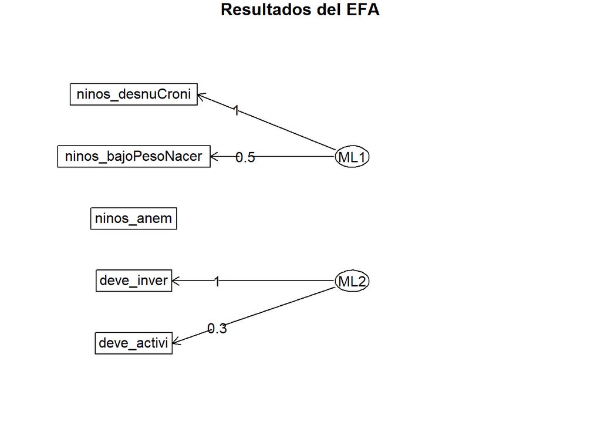

```r
fa.diagram(resfa,main = "Resultados del EFA")
```

Ud quiere obtener 5 clusters, usando:

- “Índice de Vulnerabilidad a la Inseguridad Alimentaria (IVIA)(2018)”
- “Índice de Densidad del Estado -IDE (2017)”
- “Índice de Desarrollo Humano -IDH (2019)”

Qué prefiere, kmedoides(pam) o agnes?

```r
select2=grep("ind",names(ceplan))
dataClus=ceplan[,select2]
row.names(dataClus)=ceplan$prov

library(cluster)
g.dist = daisy(dataClus, metric="gower")
```

```r
library(factoextra)
res.pam=pam(g.dist,5,cluster.only = F)
dataClus$pam=res.pam$cluster

res.agnes<- hcut(g.dist, k = 5,hc_func='agnes',hc_method = "ward.D")
dataClus$agnes=res.agnes$cluster
```

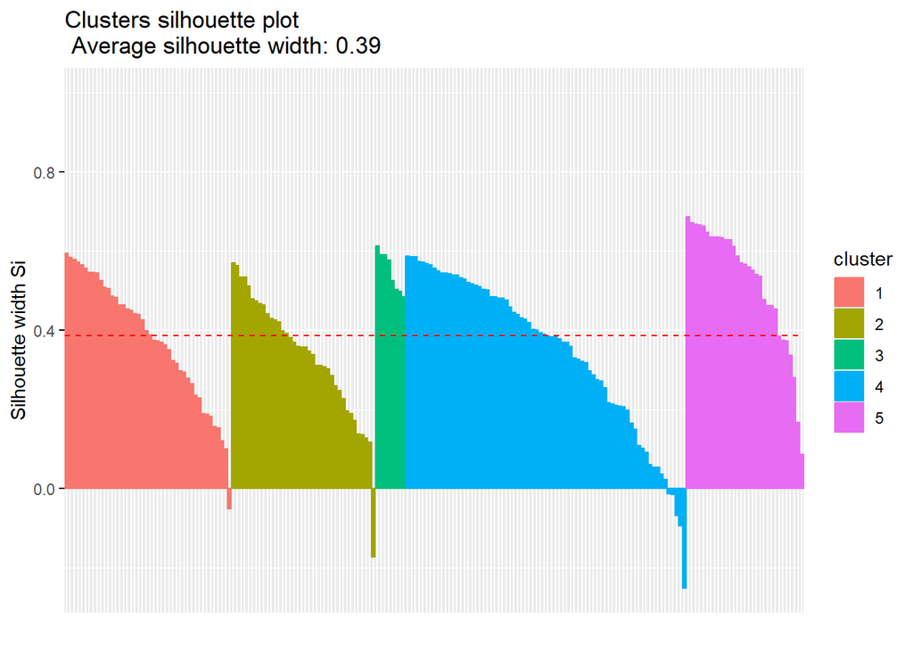

```r
fviz_silhouette(res.agnes,print.summary = F)
```

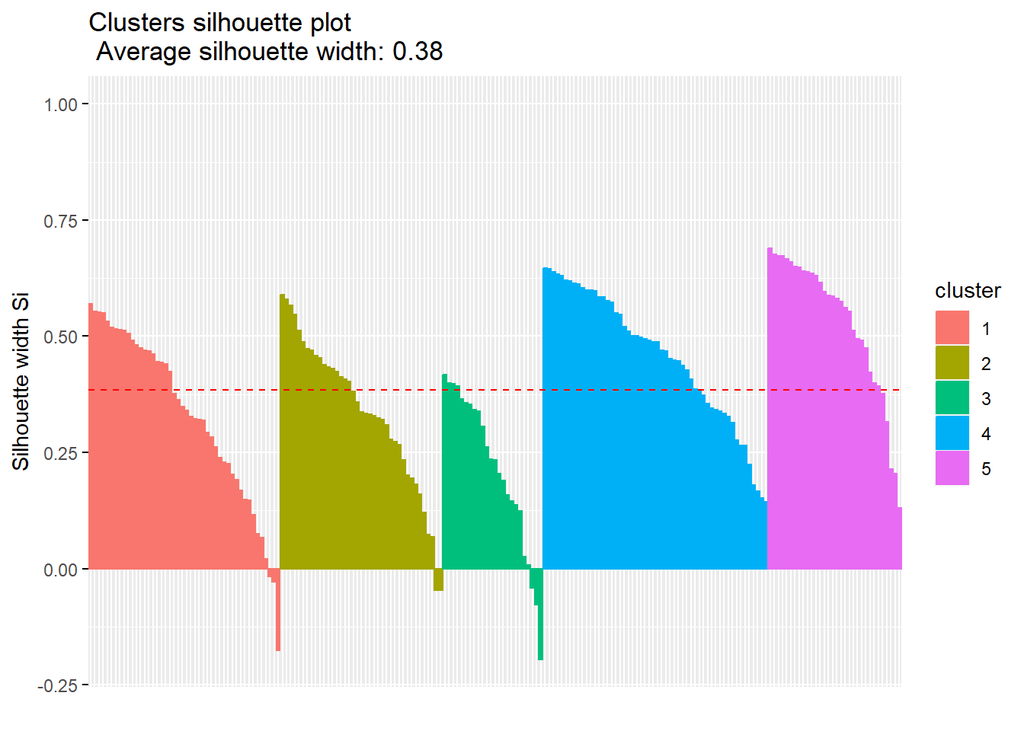

```r
fviz_silhouette(res.pam,print.summary = F)
```

```r
library(magrittr)
silAGNES=data.frame(res.agnes$silinfo$widths)
silAGNES$country=row.names(silAGNES)
poorAGNES=silAGNES[silAGNES$sil_width<0,'country']%>%sort()
poorAGNES
```

```
## [1] "BELLAVISTA" "CANDARAVE"  "CHEPÉN"     "COTABAMBAS" "LA UNIÓN"
## [6] "REQUENA"    "SANDIA"
```

```r
silPAM=data.frame(res.pam$silinfo$widths)
silPAM$country=row.names(silPAM)
poorPAM=silPAM[silPAM$sil_width<0,'country']%>%sort()
poorPAM
```

```
## [1] "AZÁNGARO"    "CANDARAVE"   "GRAN CHIMÚ"  "HUANCABAMBA" "HUAYTARÁ"
## [6] "PATAZ"       "RIOJA"       "TOCACHE"
```